# Cluster Report v3.1: PRE-COVID GoiEner

Universidad de Deusto (carlos.quesada@deusto.es)

2022-02-11 09:56:21

#### List of abbreviations

##### Sets of features

- **sAggrDRM**: seasonal aggregates v2.0 (day-referenced mean)
- **sAggrP6**: seasonal aggregates v3.0 (6-period time division)

##### Datasets

- **goi**: GoiEner (including Megara and La Corriente) [ES]

##### Clustering methods

- **som**: self-organizing maps

## sAggrP6 > goi > som

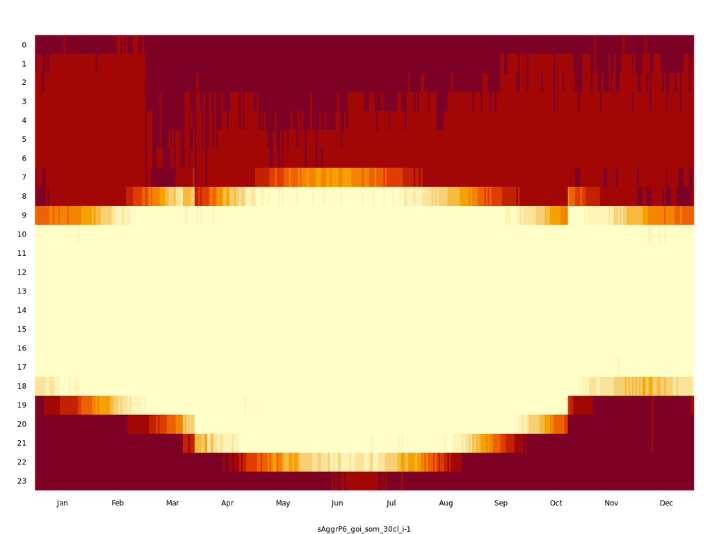

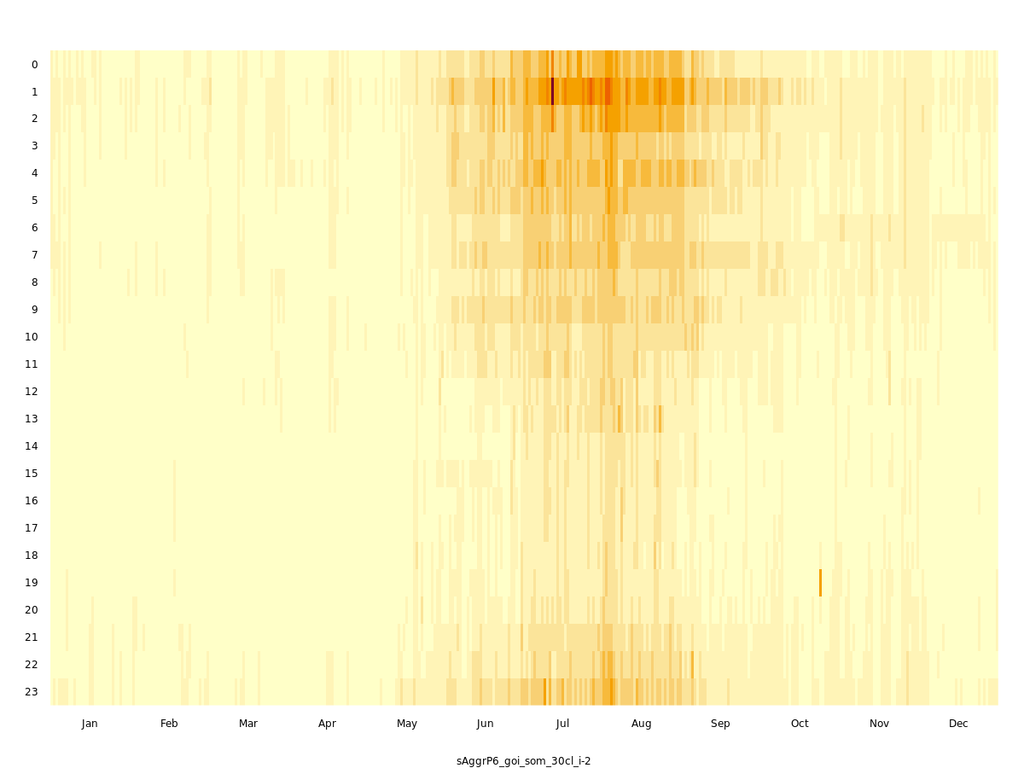

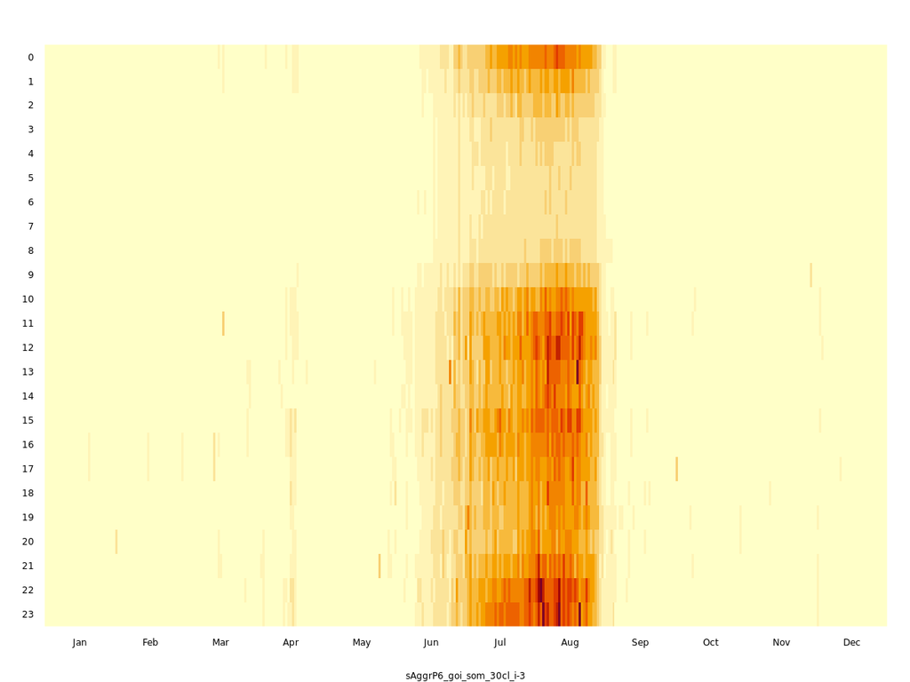

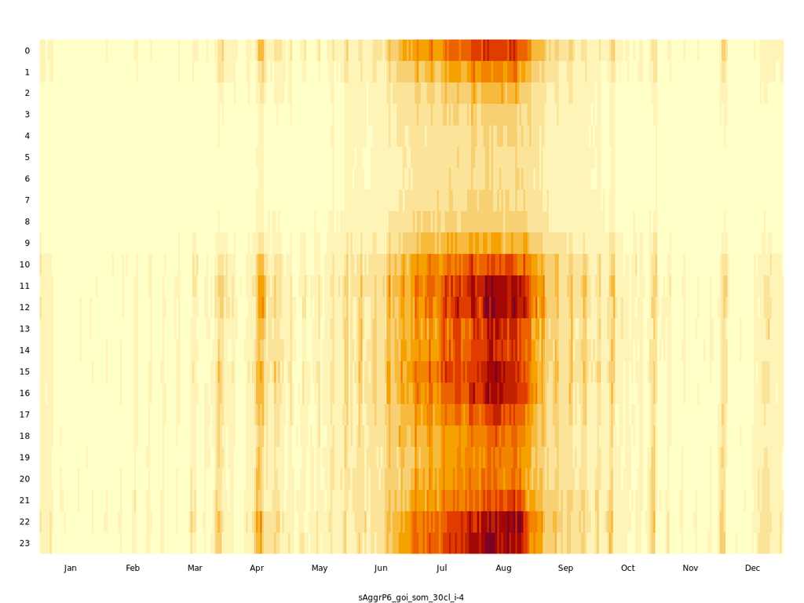

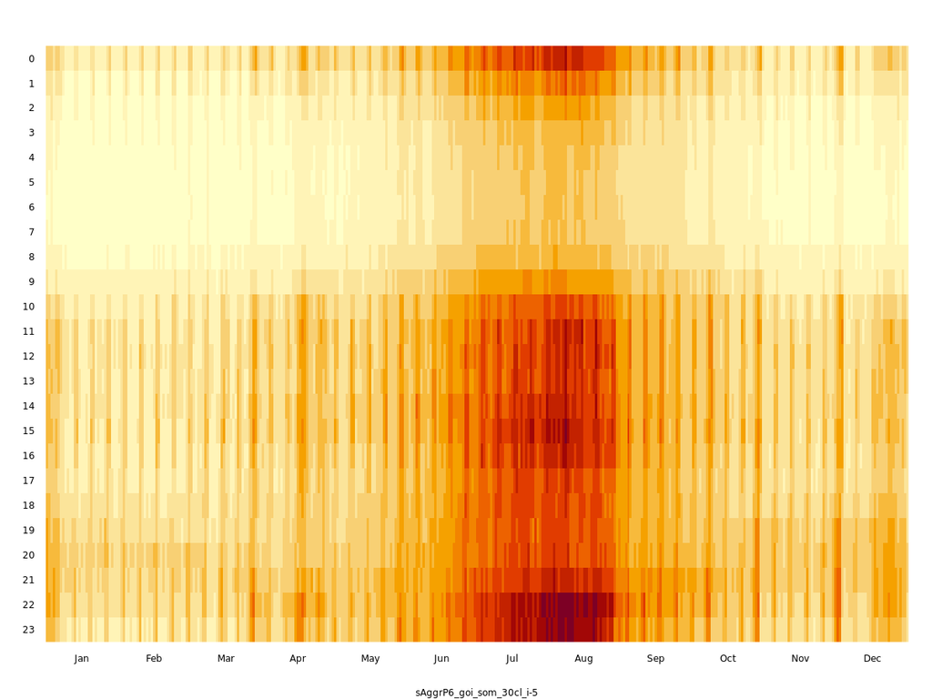

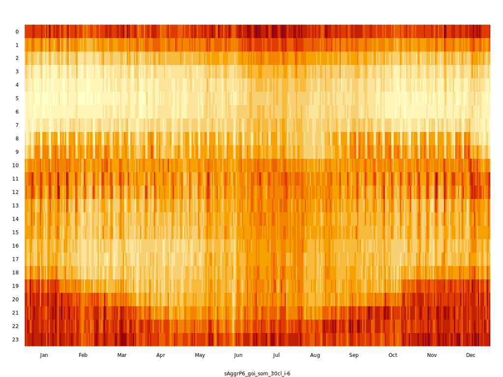

sAggrP6 > goi > som > #1

230 TS (1.9%)

sAggrP6 > goi > som > #2

24 TS (0.2%)

sAggrP6 > goi > som > #3

67 TS (0.6%)

sAggrP6 > goi > som > #4

172 TS (1.4%)

sAggrP6 > goi > som > #5

484 TS (4%)

sAggrP6 > goi > som > #6

713 TS (5.9%)

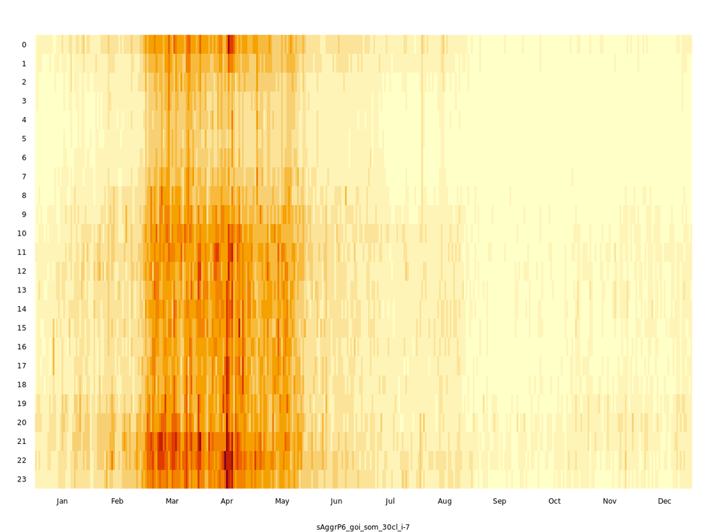

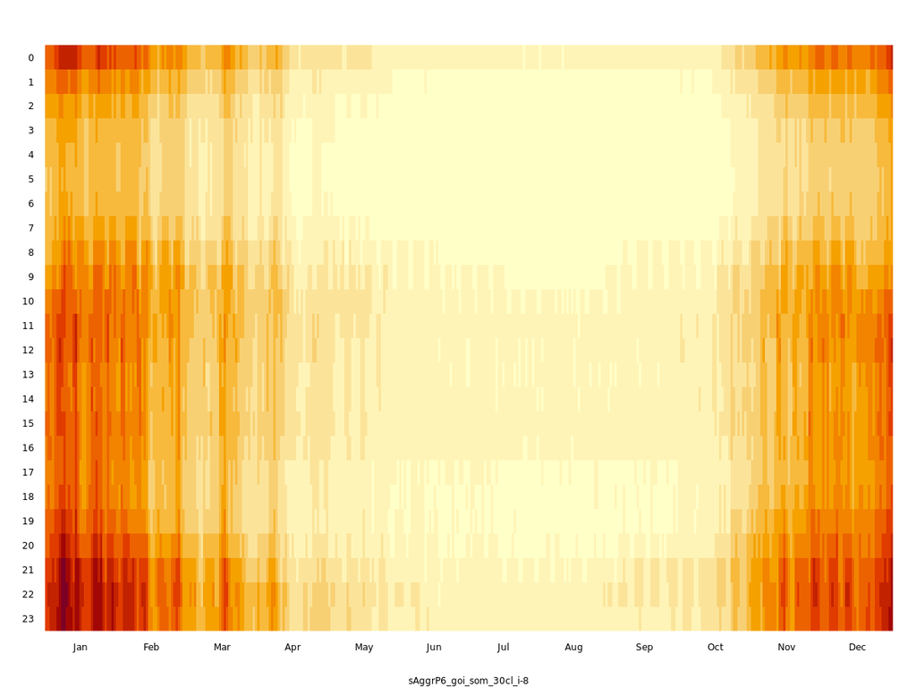

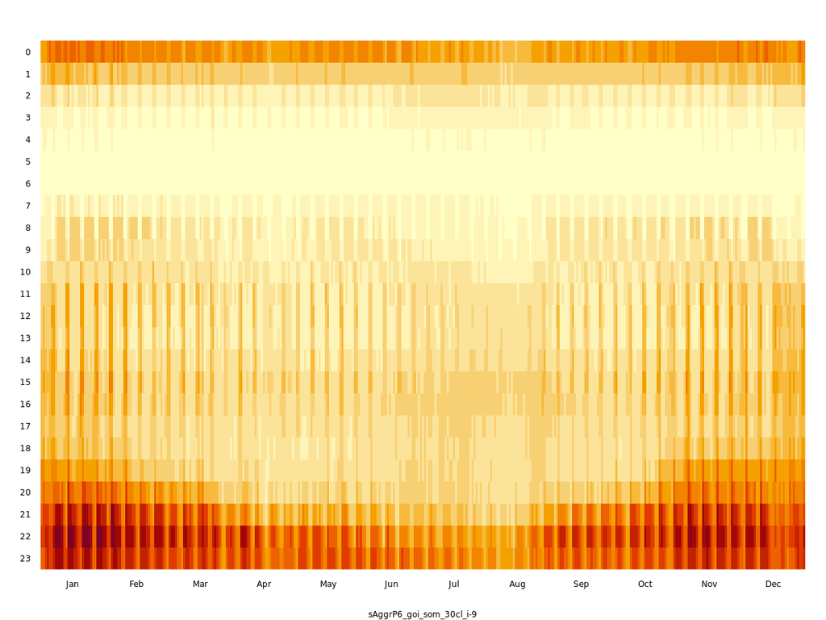

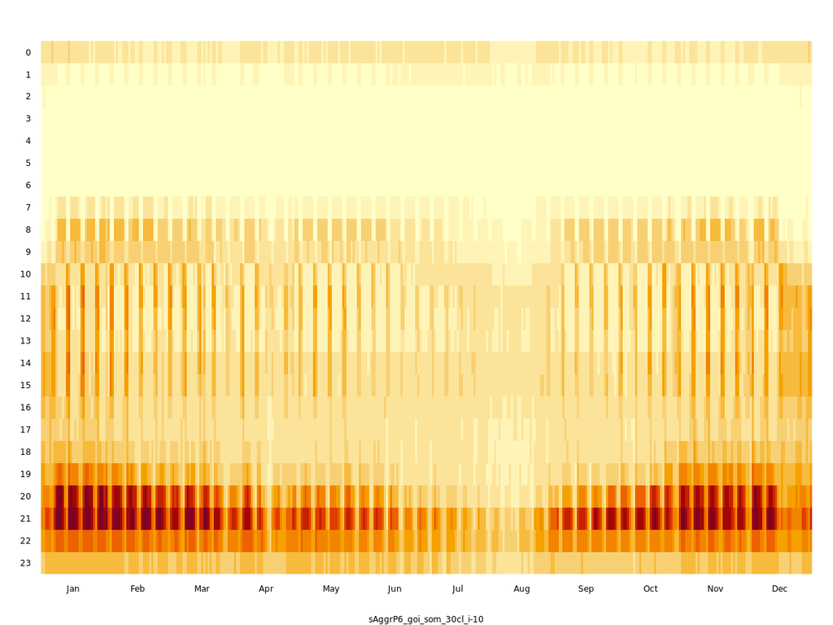

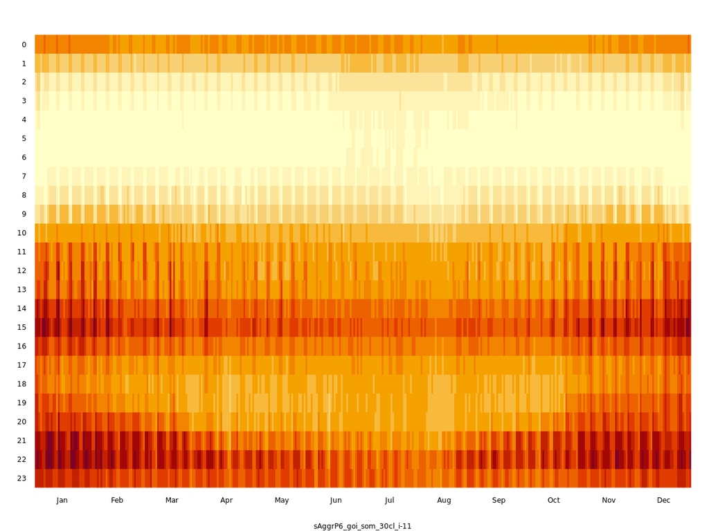

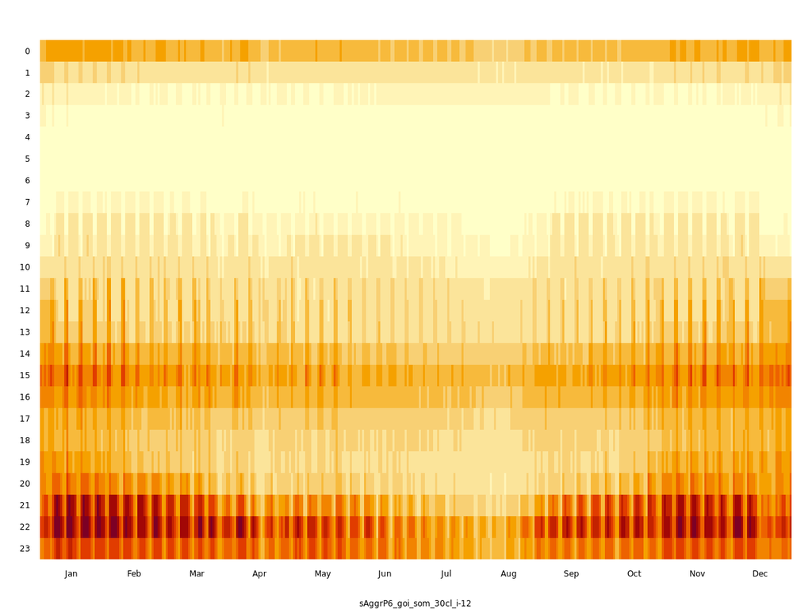

sAggrP6 > goi > som > #7

87 TS (0.7%)

sAggrP6 > goi > som > #8

446 TS (3.7%)

sAggrP6 > goi > som > #9

980 TS (8.2%)

sAggrP6 > goi > som > #10

687 TS (5.7%)

sAggrP6 > goi > som > #11

1083 TS (9%)

sAggrP6 > goi > som > #12

775 TS (6.5%)

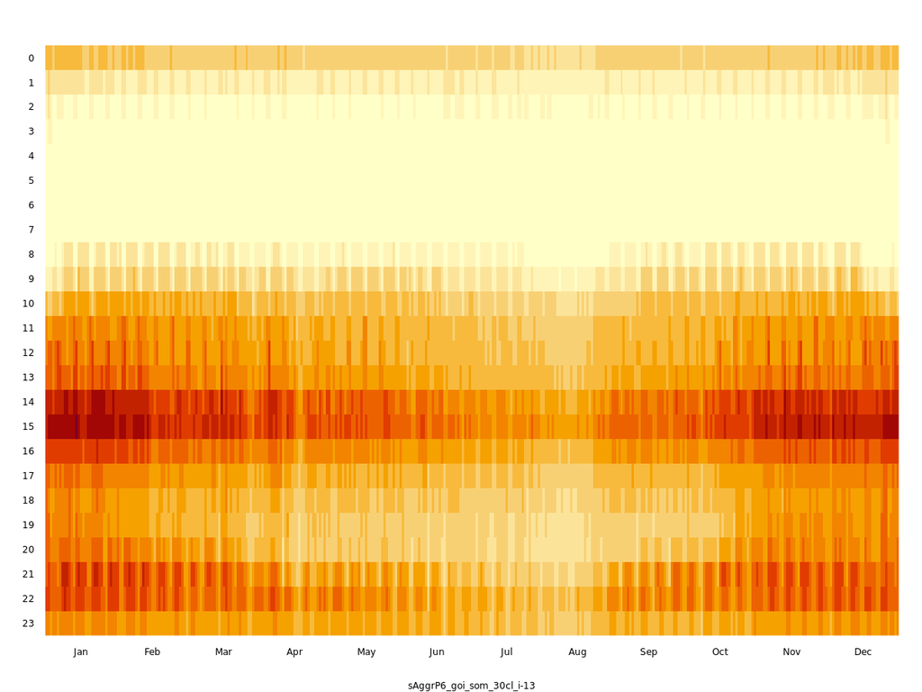

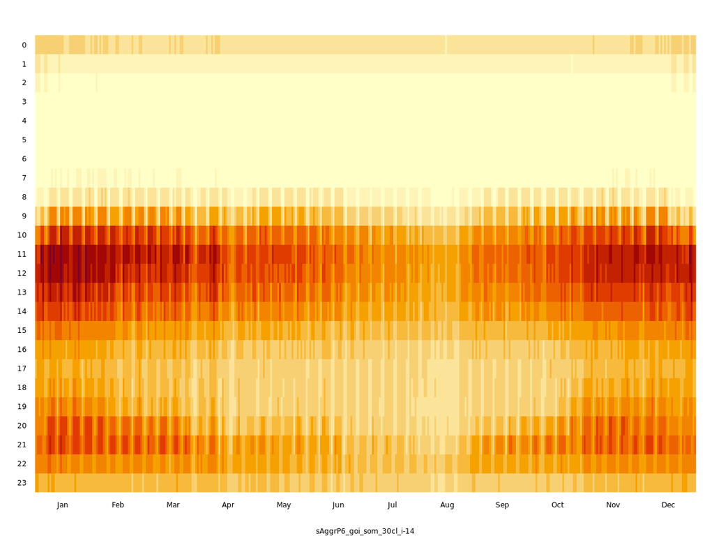

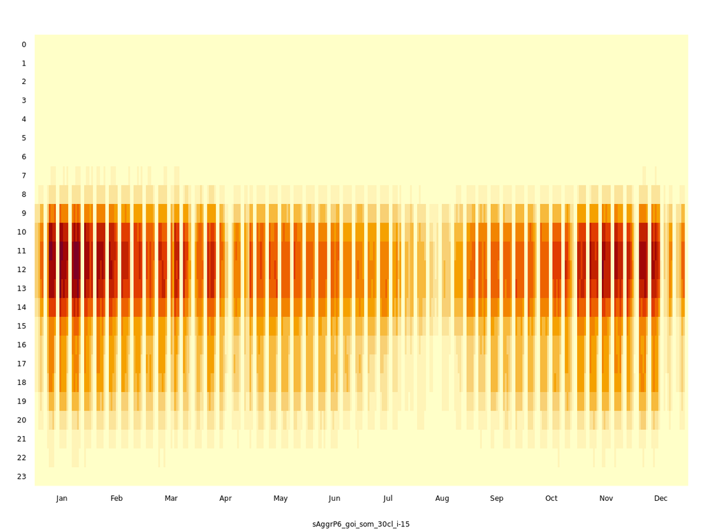

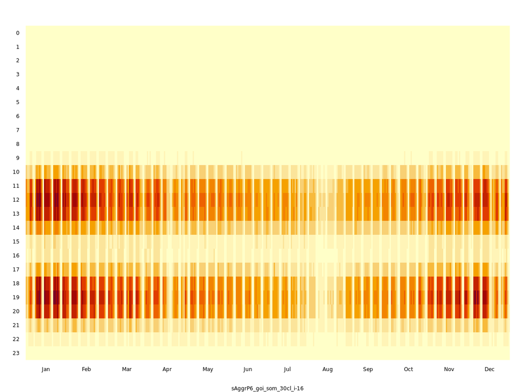

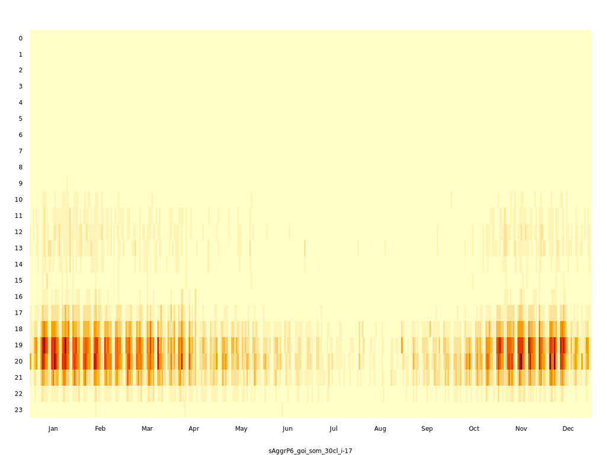

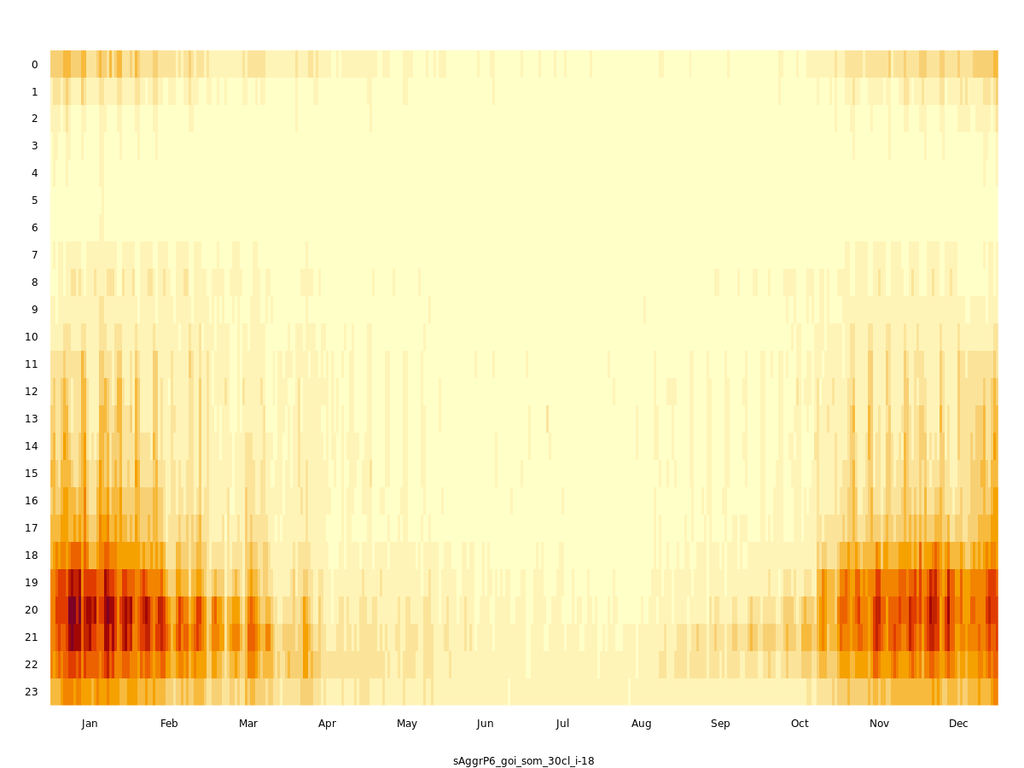

sAggrP6 > goi > som > #13

634 TS (5.3%)

sAggrP6 > goi > som > #14

712 TS (5.9%)

sAggrP6 > goi > som > #15

218 TS (1.8%)

sAggrP6 > goi > som > #16

160 TS (1.3%)

sAggrP6 > goi > som > #17

69 TS (0.6%)

sAggrP6 > goi > som > #18

106 TS (0.9%)

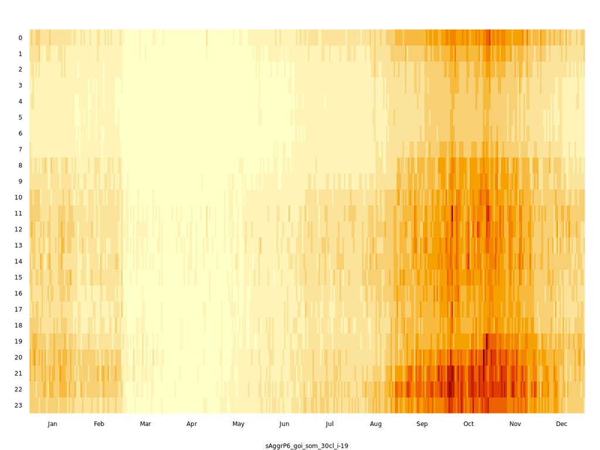

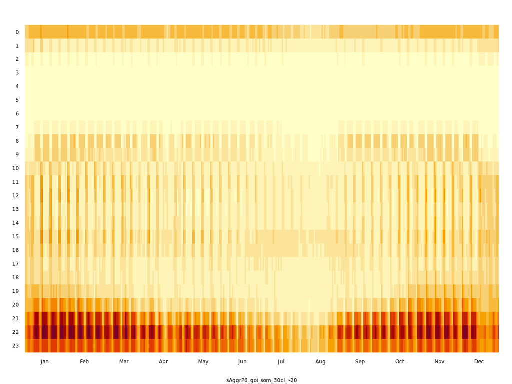

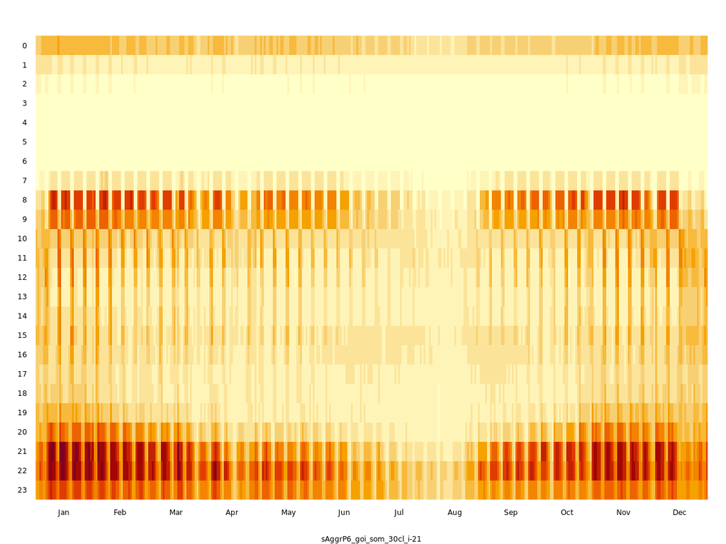

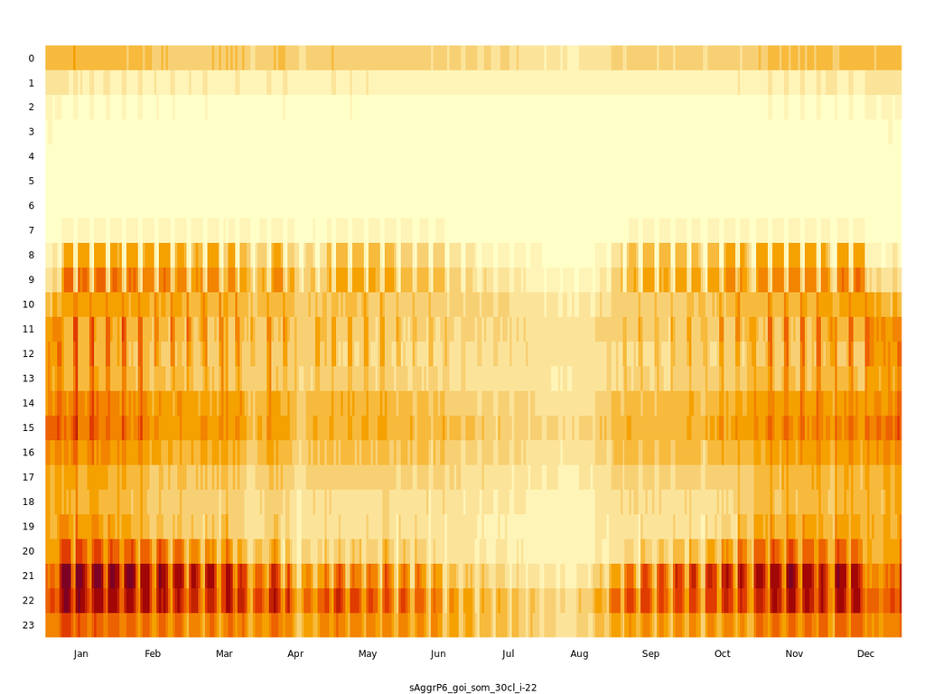

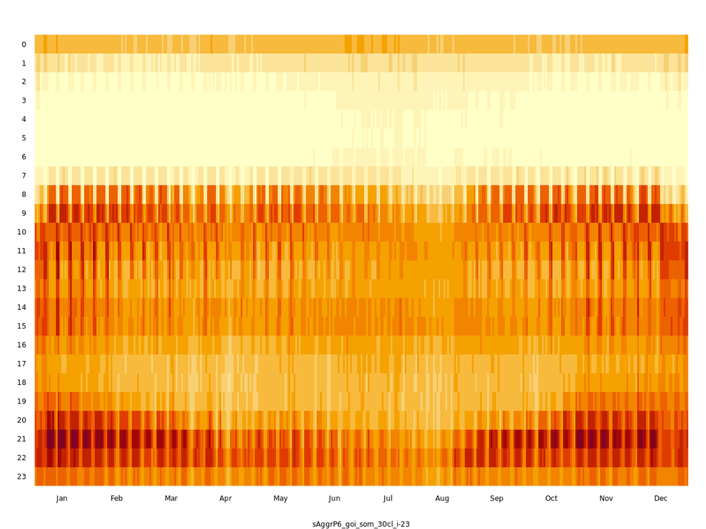

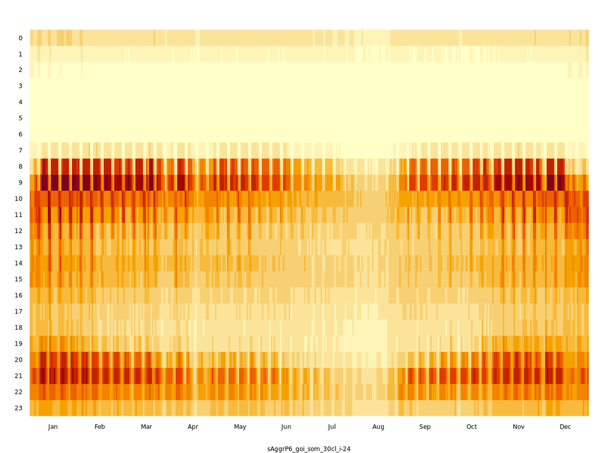

sAggrP6 > goi > som > #19

112 TS (0.9%)

sAggrP6 > goi > som > #20

655 TS (5.5%)

sAggrP6 > goi > som > #21

626 TS (5.2%)

sAggrP6 > goi > som > #22

935 TS (7.8%)

sAggrP6 > goi > som > #23

864 TS (7.2%)

sAggrP6 > goi > som > #24

520 TS (4.3%)

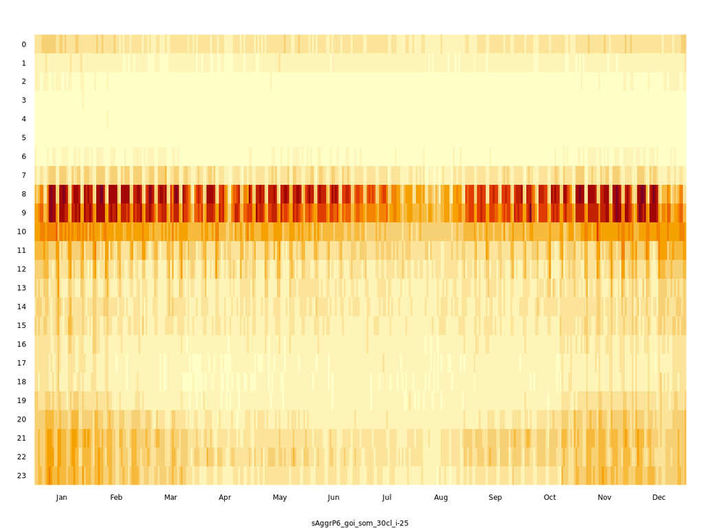

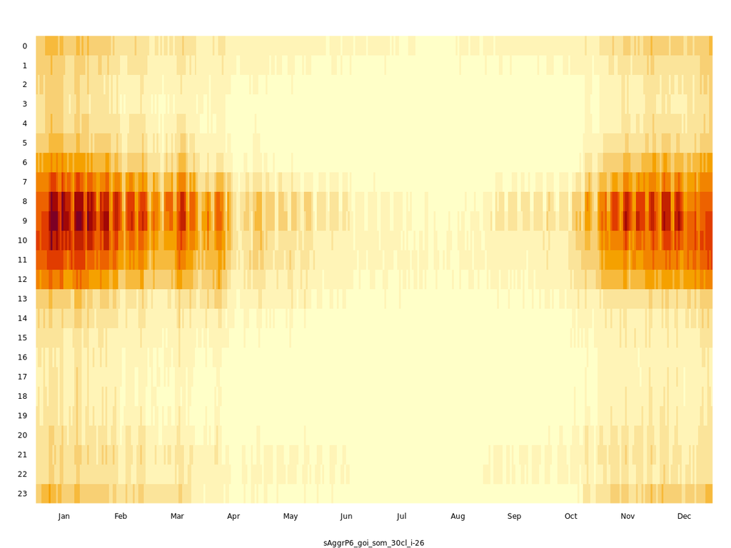

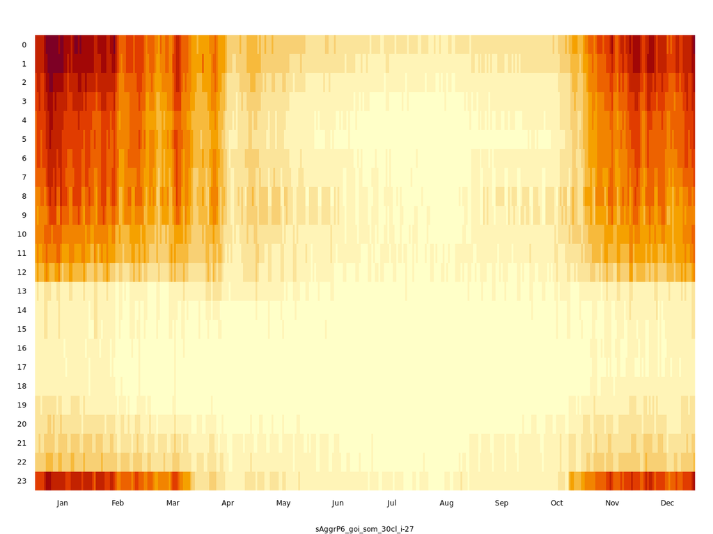

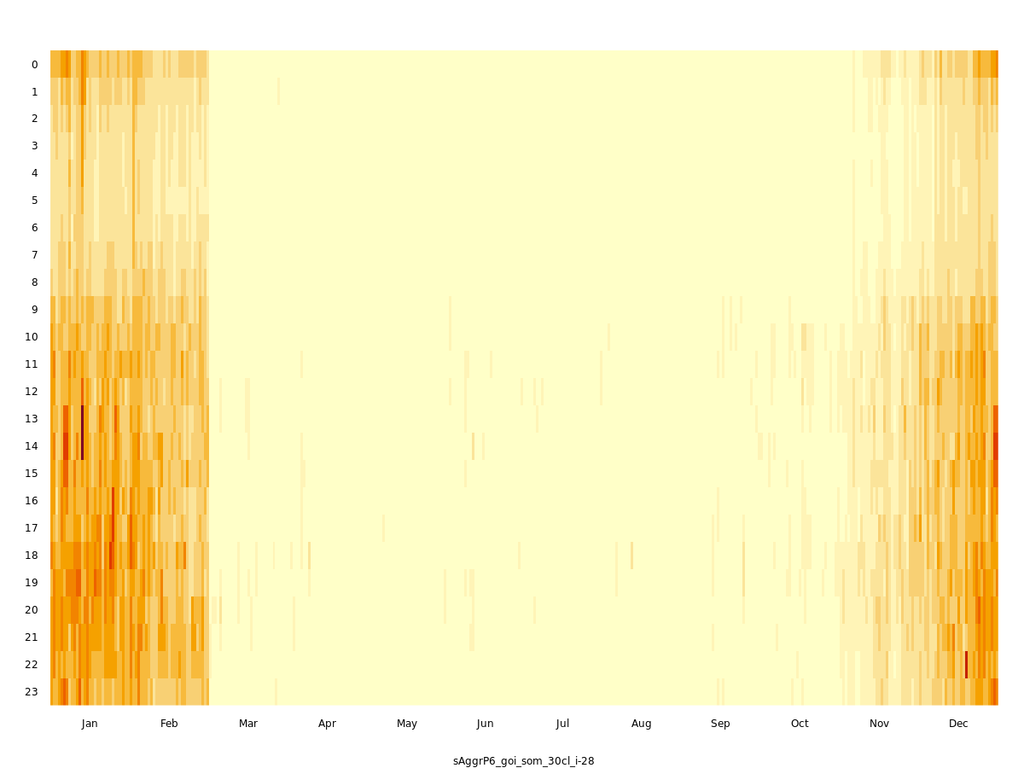

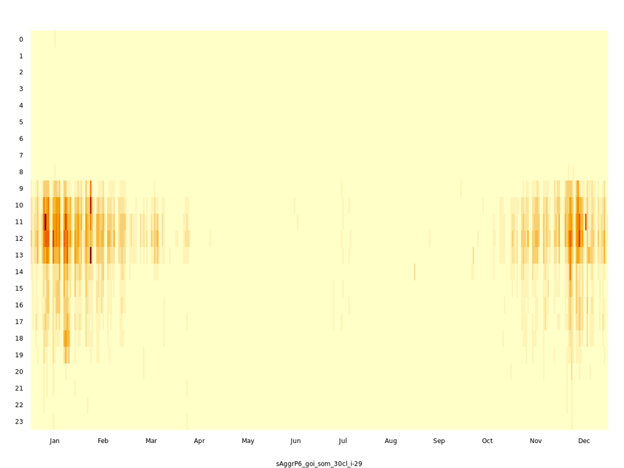

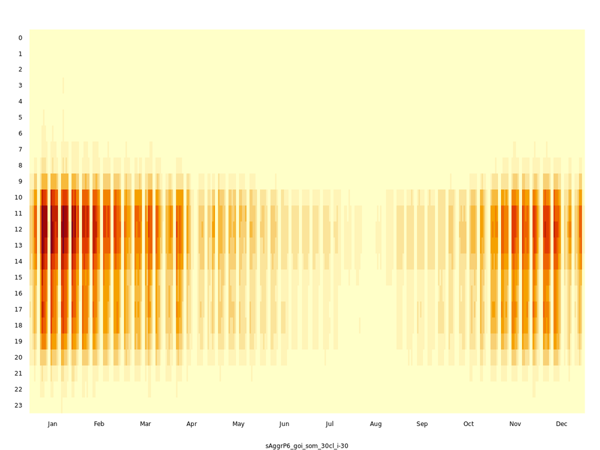

sAggrP6 > goi > som > #25

79 TS (0.7%)

sAggrP6 > goi > som > #26

103 TS (0.9%)

sAggrP6 > goi > som > #27

189 TS (1.6%)

sAggrP6 > goi > som > #28

57 TS (0.5%)

sAggrP6 > goi > som > #29

22 TS (0.2%)

sAggrP6 > goi > som > #30

189 TS (1.6%)

## sAggrDRM > goi > som

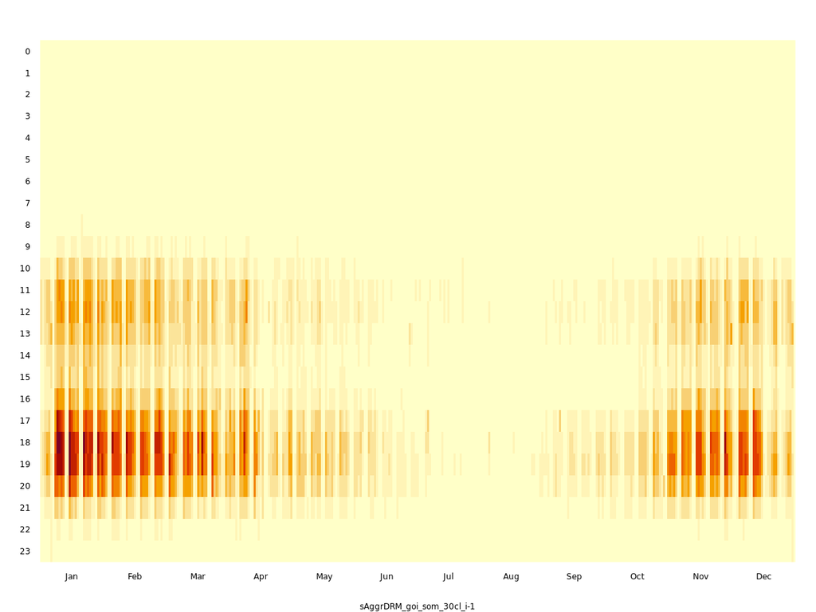

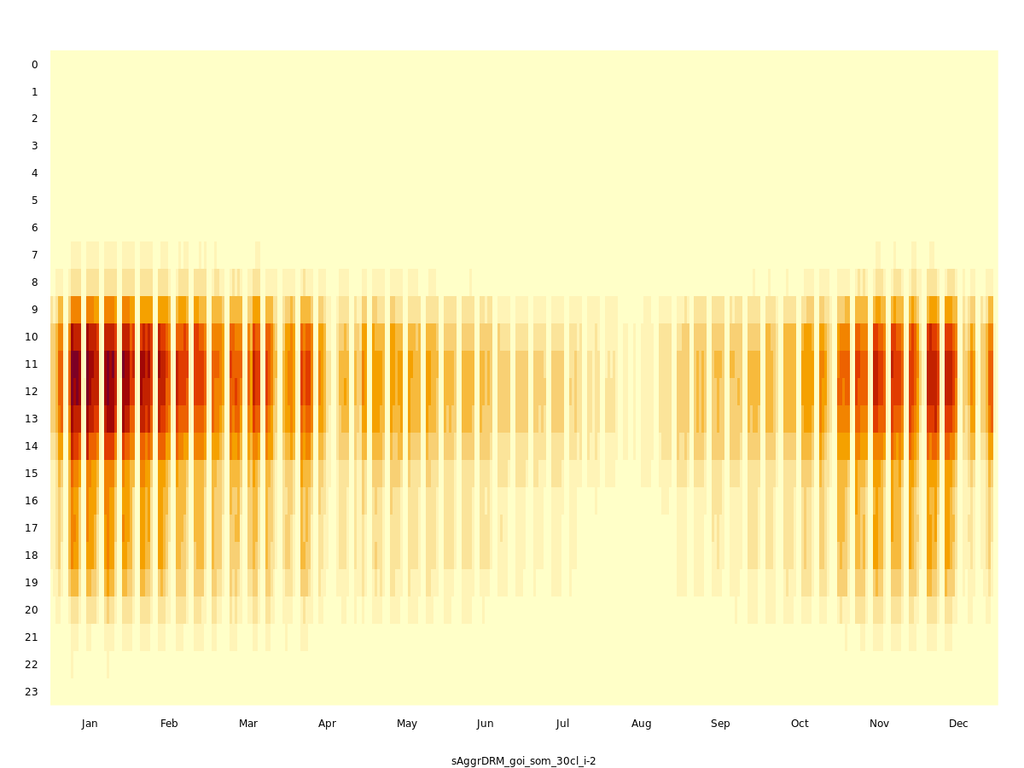

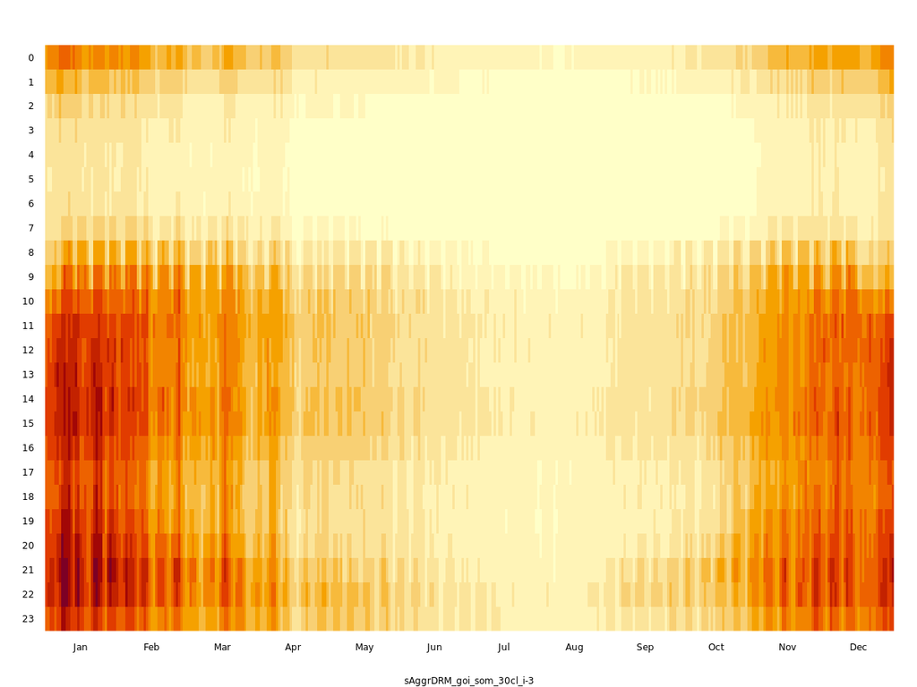

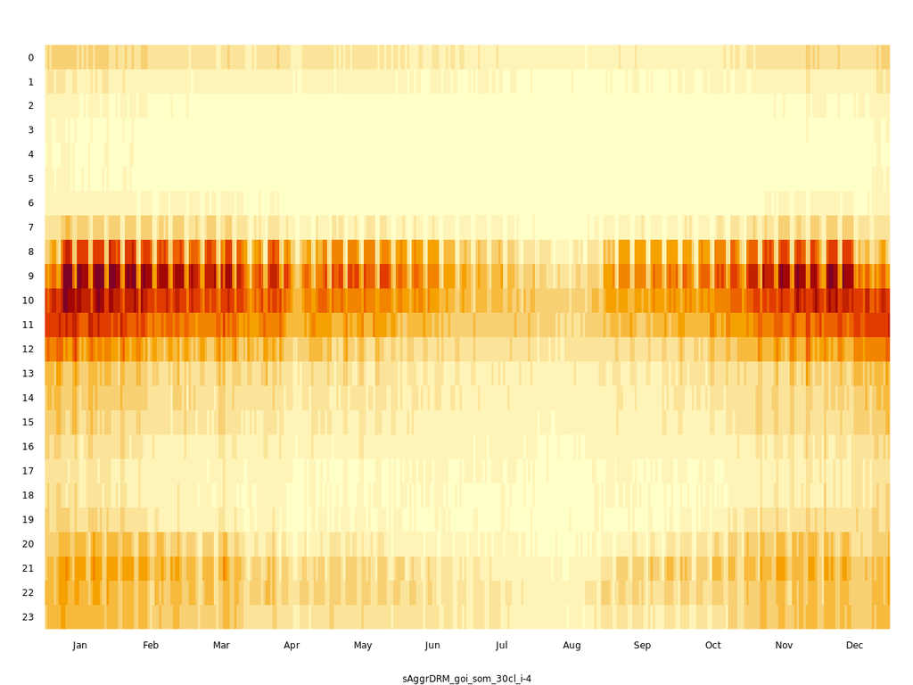

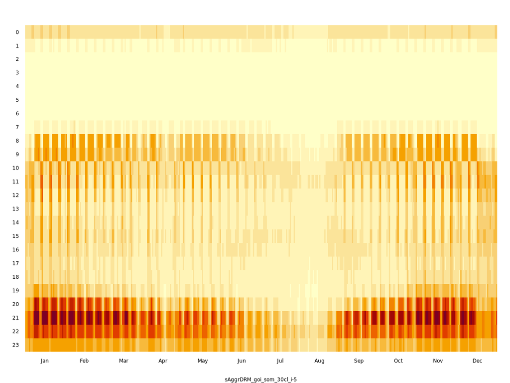

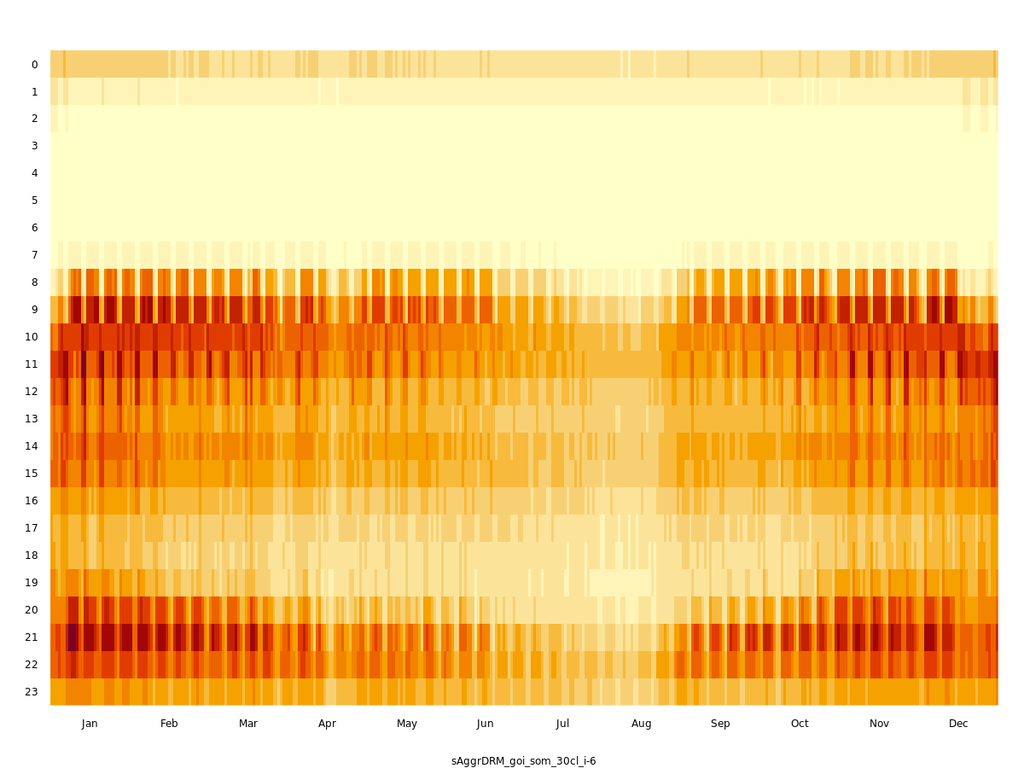

sAggrDRM > goi > som > #1

68 TS (0.6%)

sAggrDRM > goi > som > #2

274 TS (2.3%)

sAggrDRM > goi > som > #3

342 TS (2.9%)

sAggrDRM > goi > som > #4

195 TS (1.6%)

sAggrDRM > goi > som > #5

681 TS (5.7%)

sAggrDRM > goi > som > #6

619 TS (5.2%)

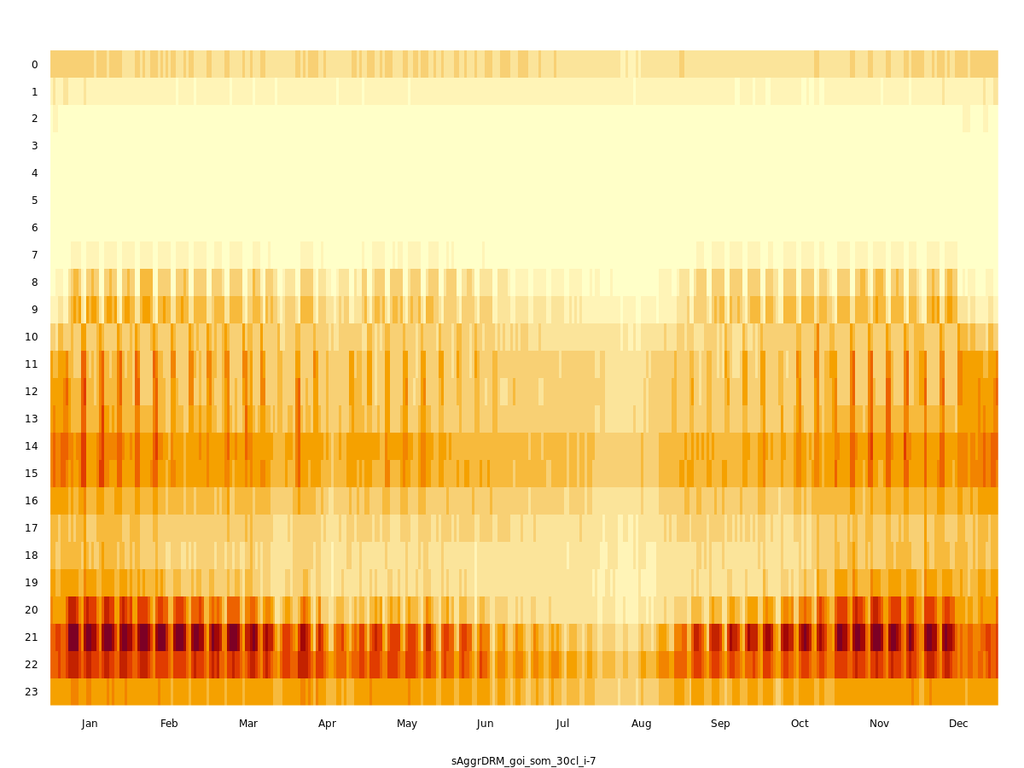

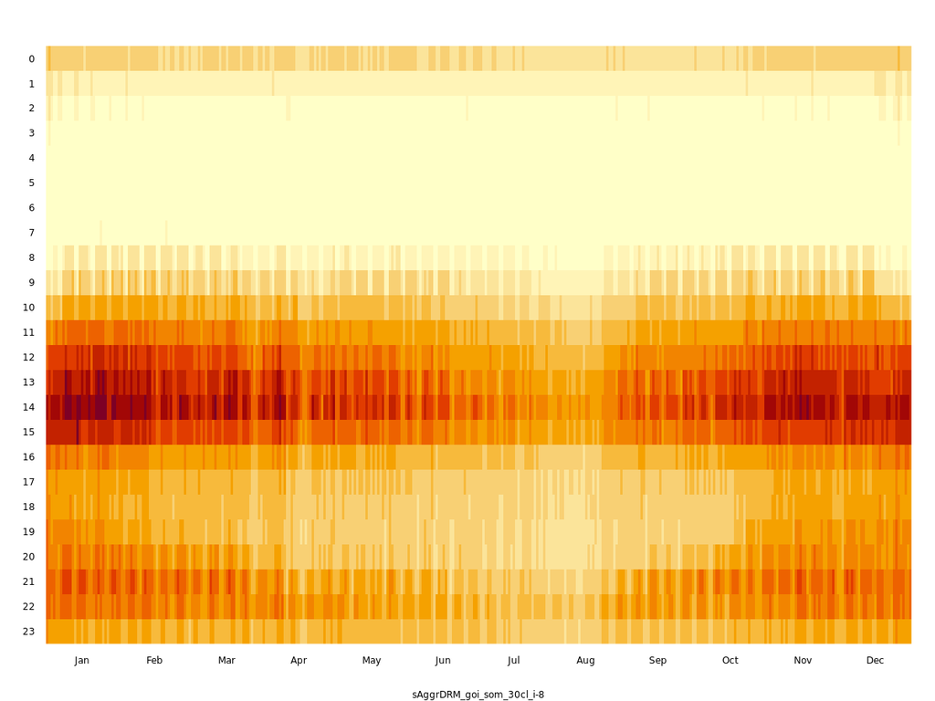

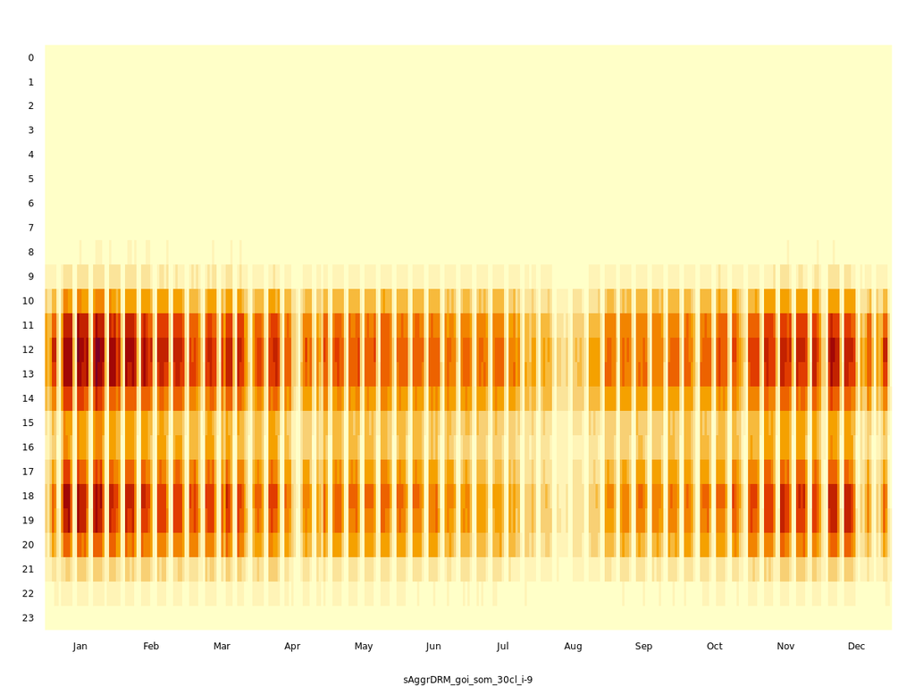

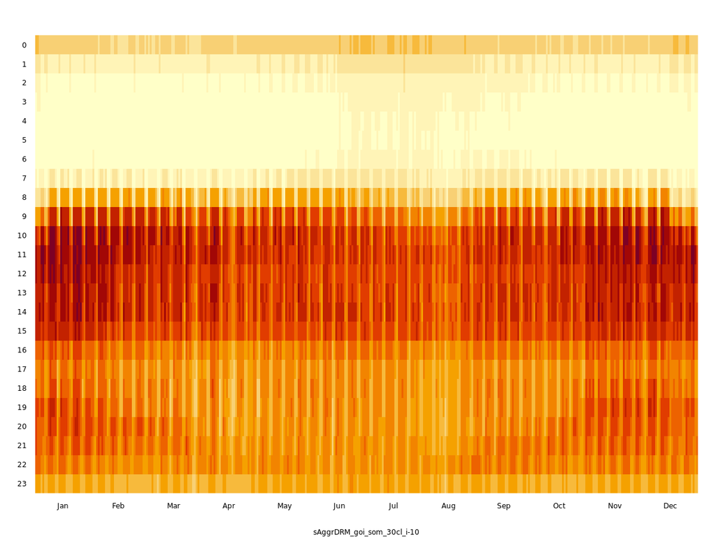

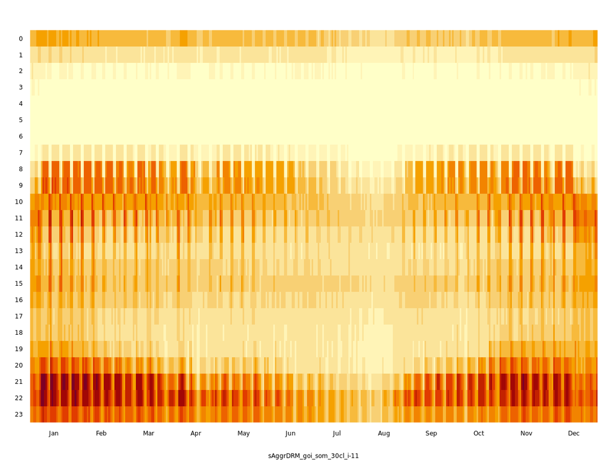

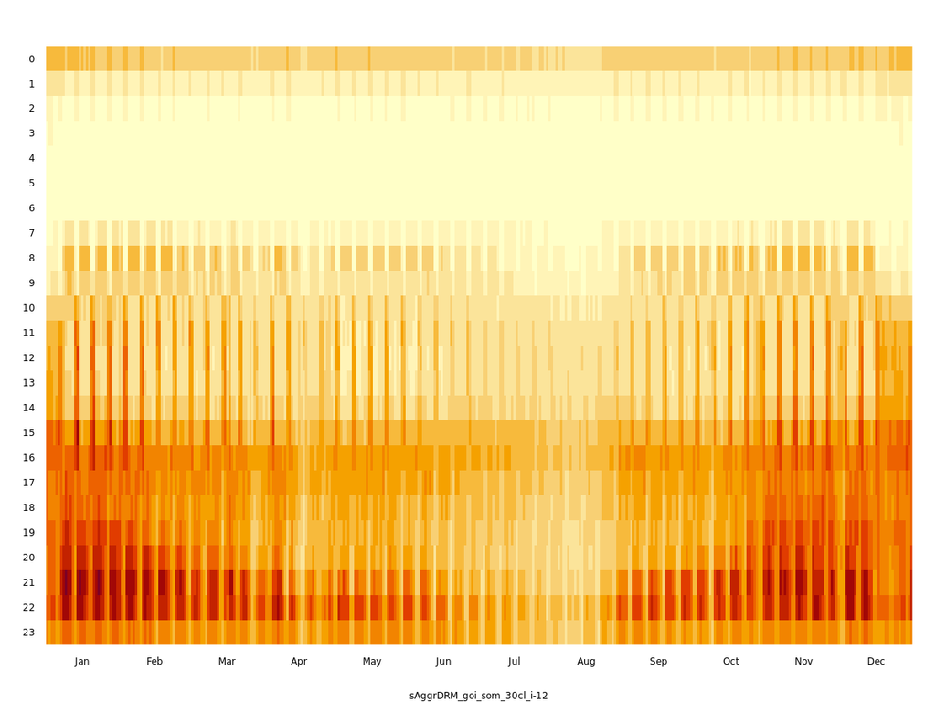

sAggrDRM > goi > som > #7

758 TS (6.3%)

sAggrDRM > goi > som > #8

442 TS (3.7%)

sAggrDRM > goi > som > #9

223 TS (1.9%)

sAggrDRM > goi > som > #10

615 TS (5.1%)

sAggrDRM > goi > som > #11

1003 TS (8.4%)

sAggrDRM > goi > som > #12

519 TS (4.3%)

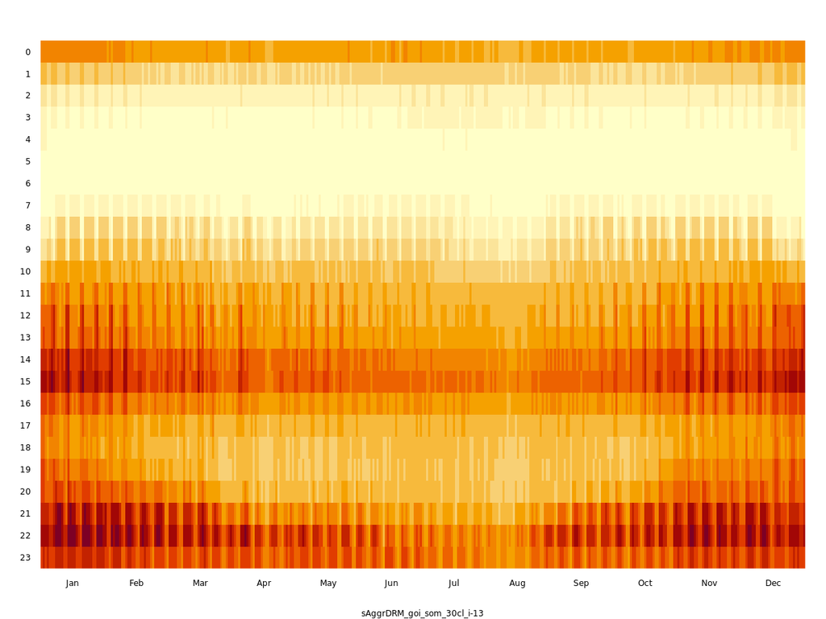

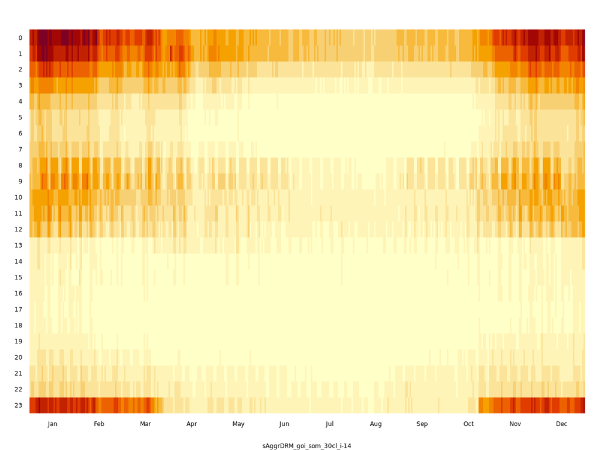

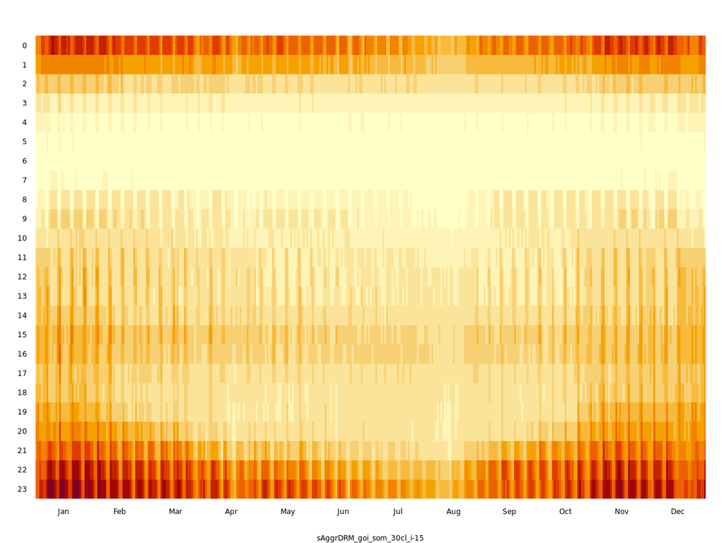

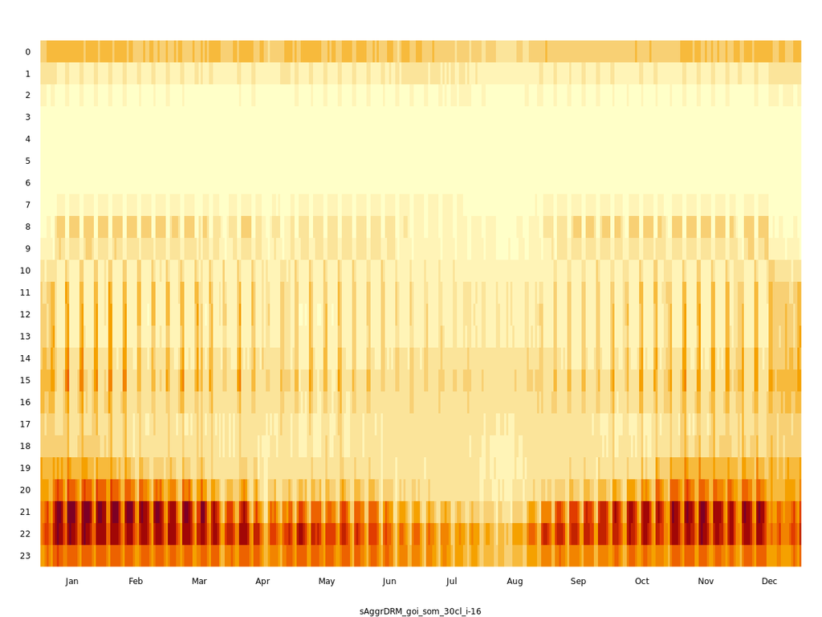

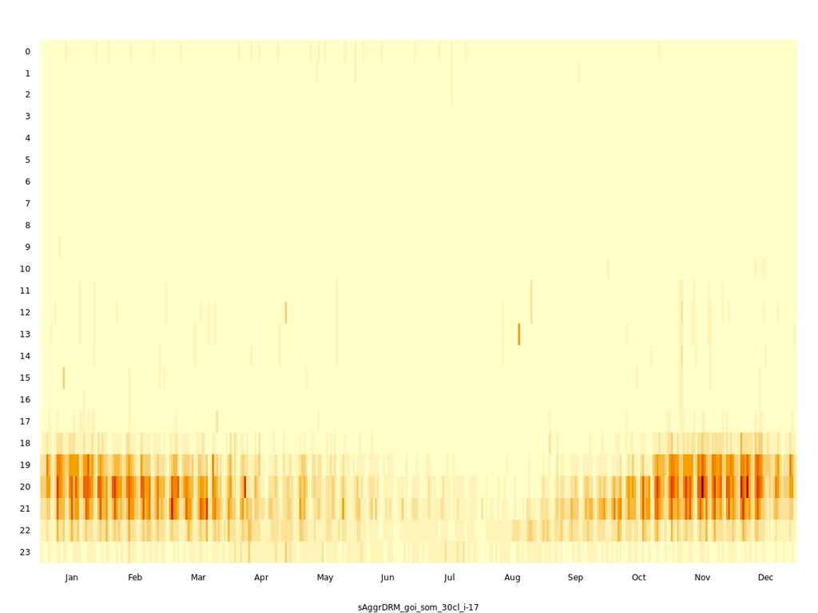

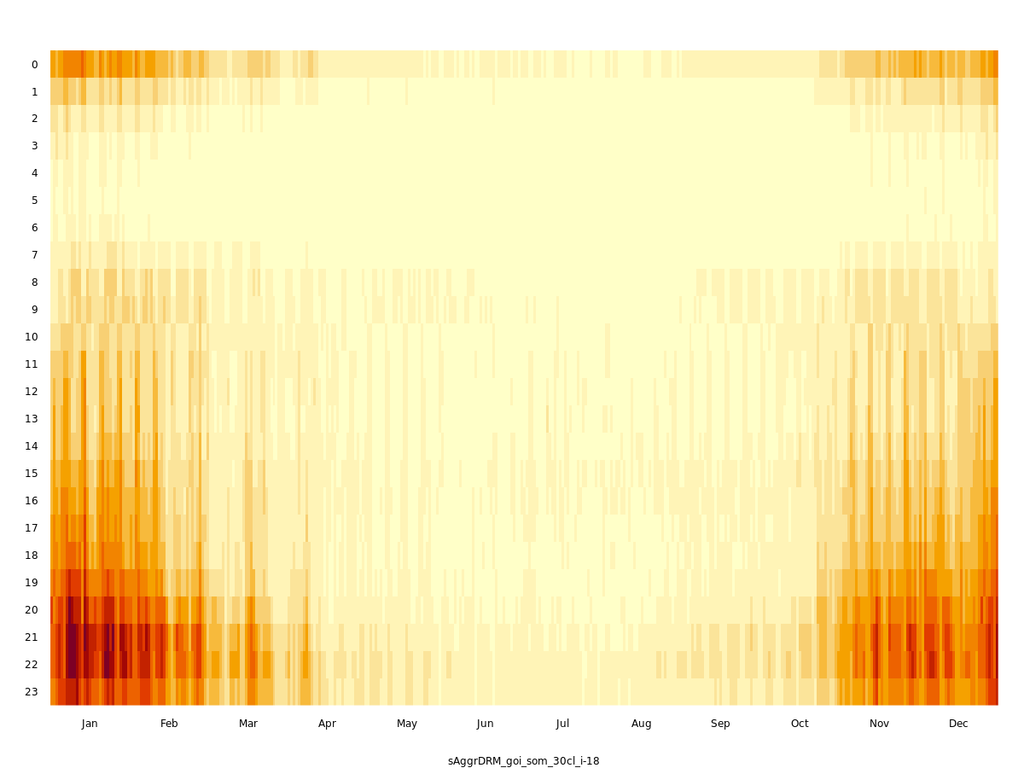

sAggrDRM > goi > som > #13

1062 TS (8.9%)

sAggrDRM > goi > som > #14

112 TS (0.9%)

sAggrDRM > goi > som > #15

582 TS (4.9%)

sAggrDRM > goi > som > #16

849 TS (7.1%)

sAggrDRM > goi > som > #17

44 TS (0.4%)

sAggrDRM > goi > som > #18

167 TS (1.4%)

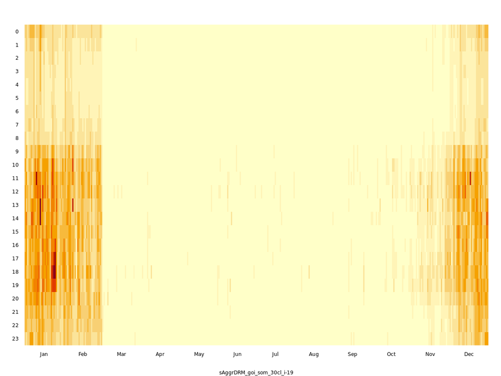

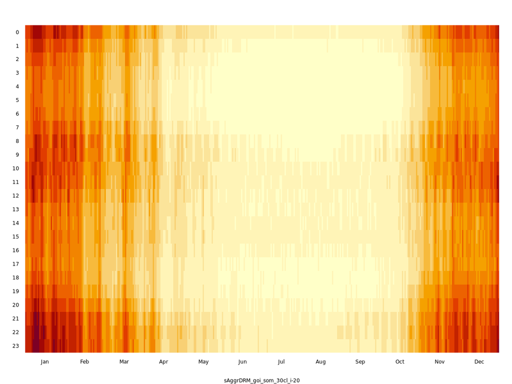

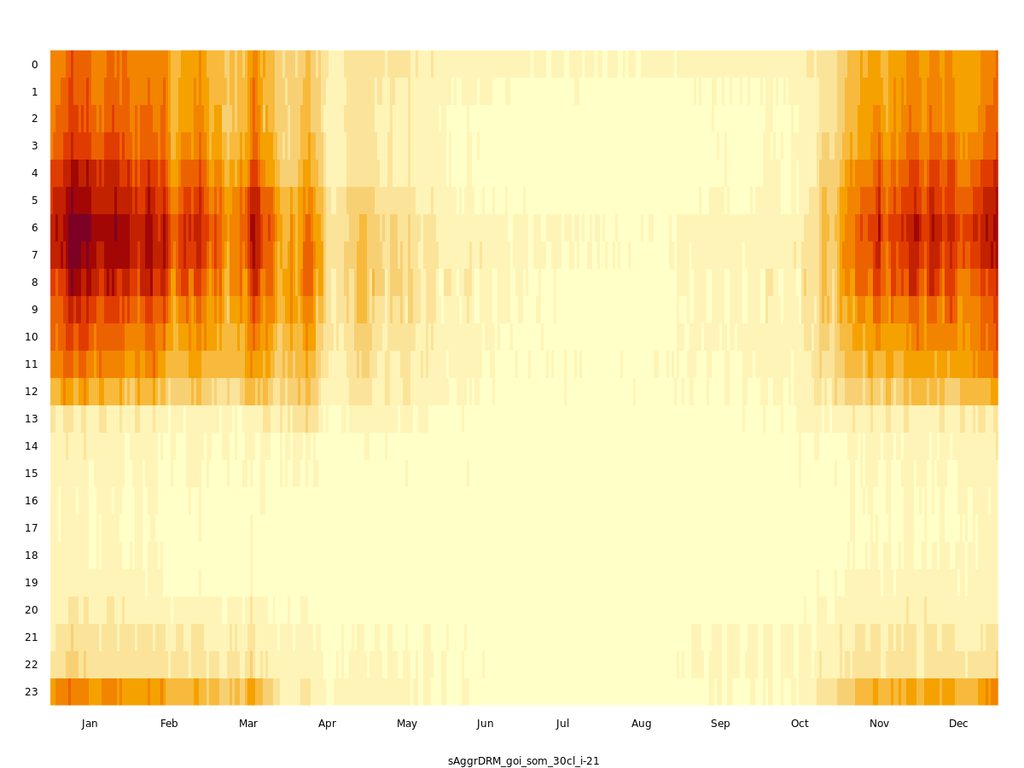

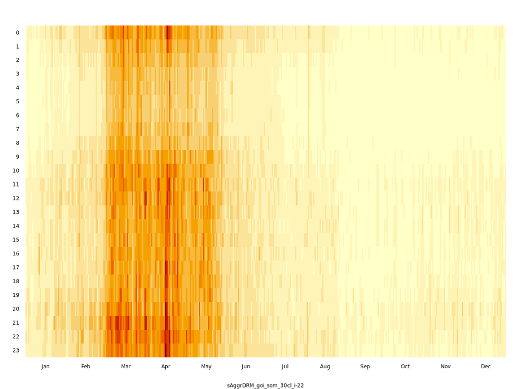

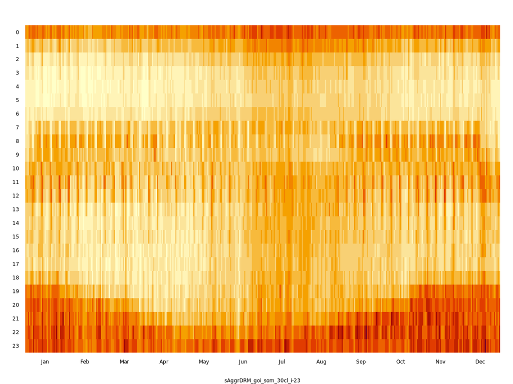

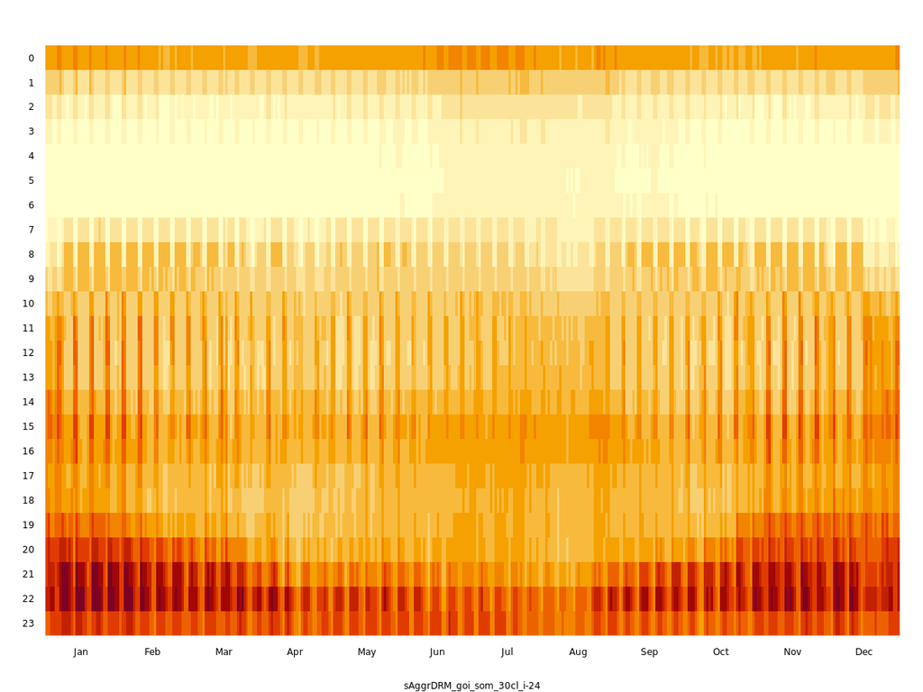

sAggrDRM > goi > som > #19

61 TS (0.5%)

sAggrDRM > goi > som > #20

282 TS (2.4%)

sAggrDRM > goi > som > #21

128 TS (1.1%)

sAggrDRM > goi > som > #22

79 TS (0.7%)

sAggrDRM > goi > som > #23

642 TS (5.4%)

sAggrDRM > goi > som > #24

1226 TS (10.2%)

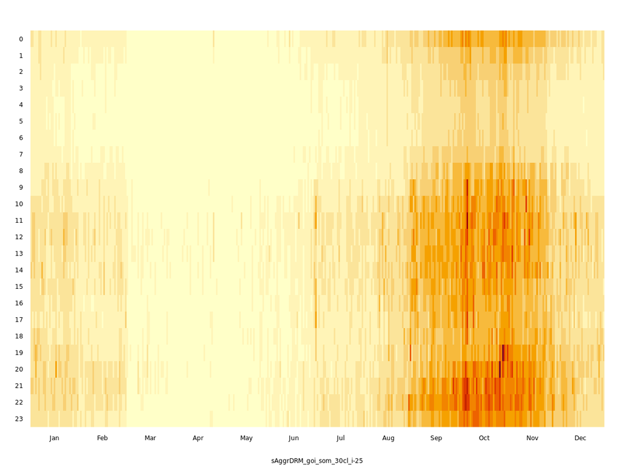

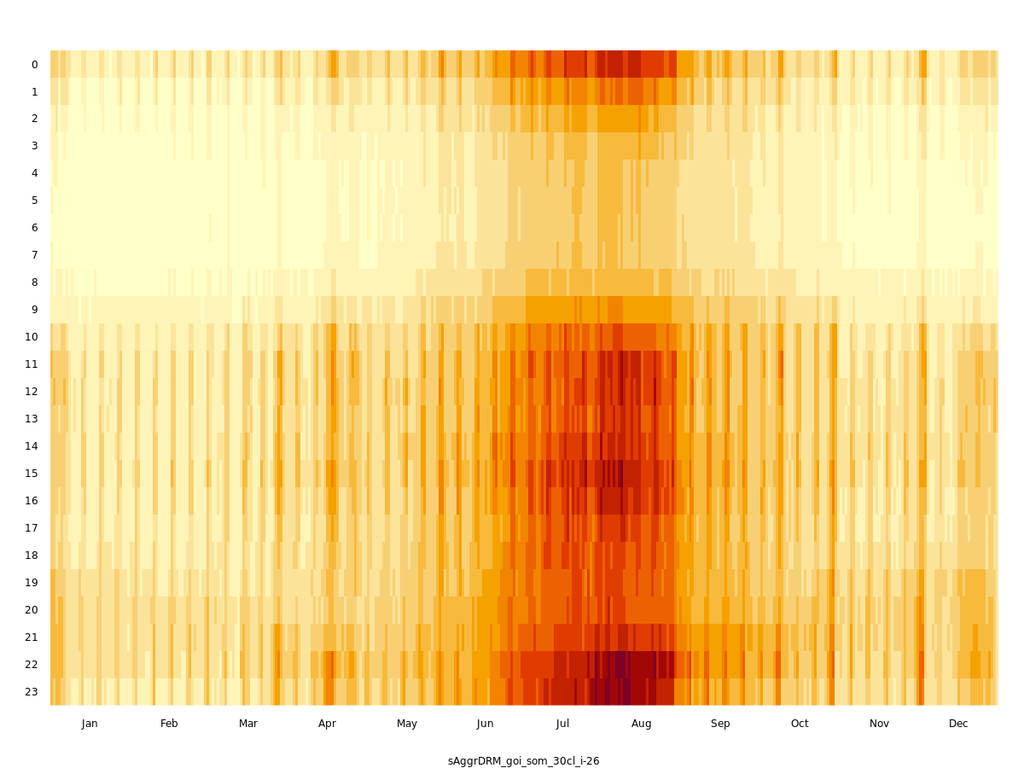

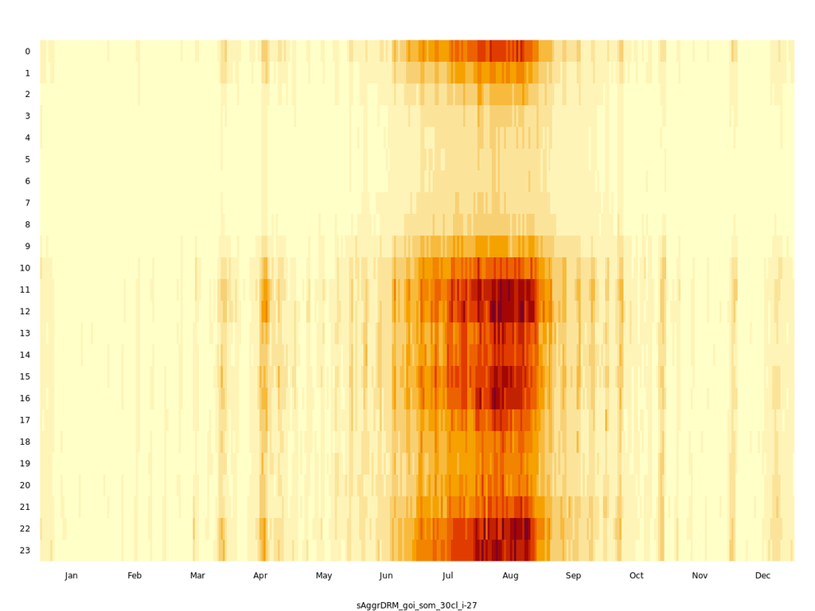

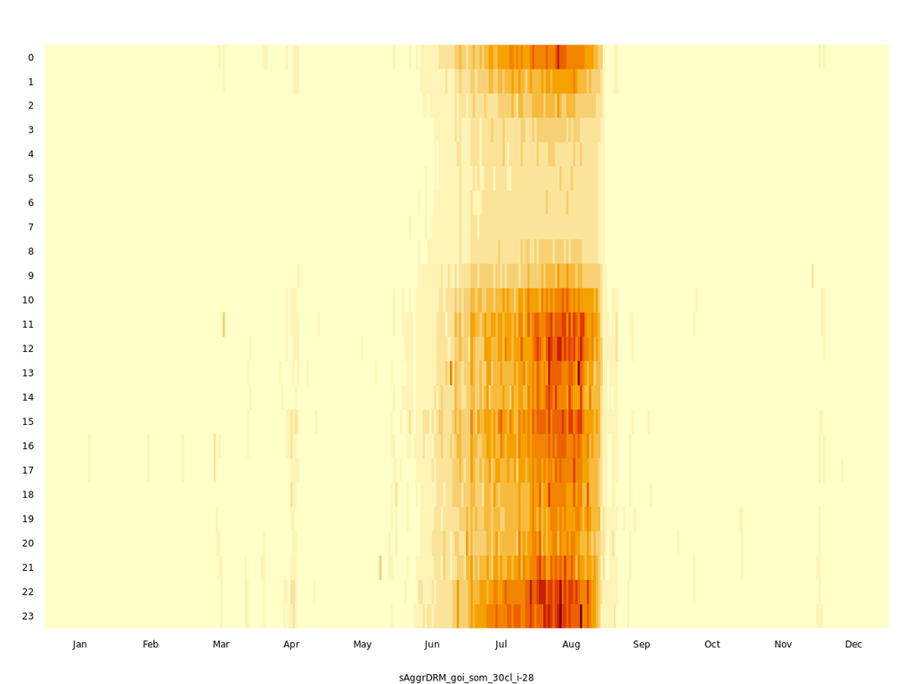

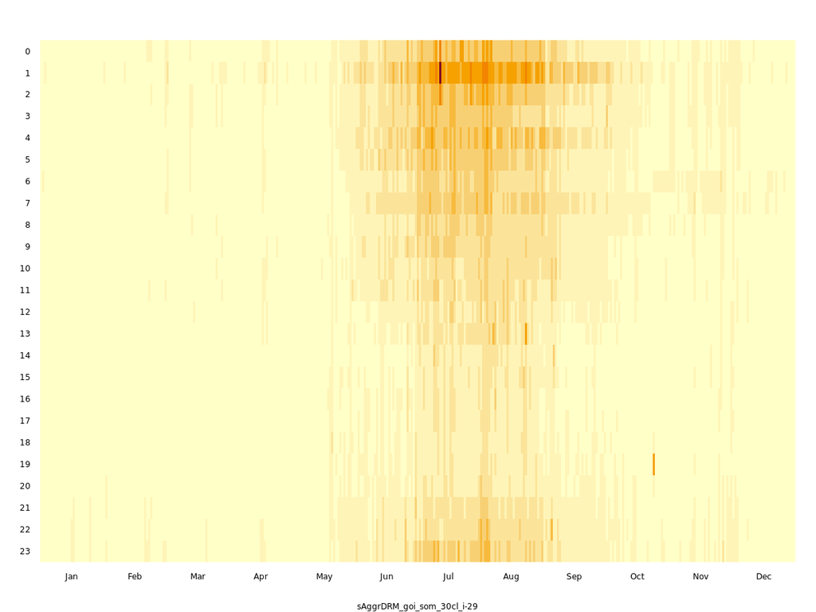

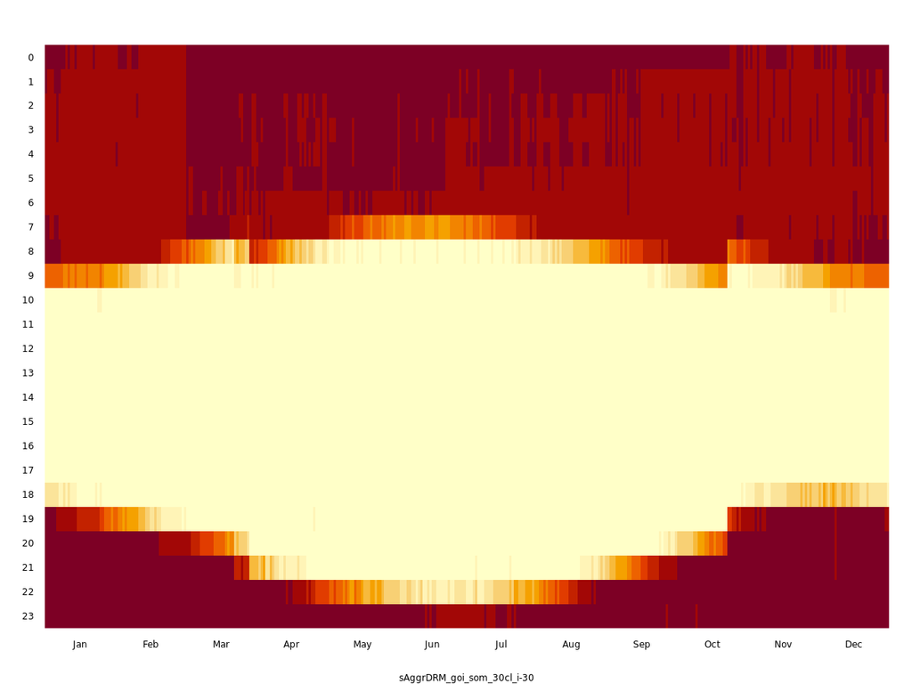

sAggrDRM > goi > som > #25

90 TS (0.8%)

sAggrDRM > goi > som > #26

452 TS (3.8%)

sAggrDRM > goi > som > #27

158 TS (1.3%)

sAggrDRM > goi > som > #28

69 TS (0.6%)

sAggrDRM > goi > som > #29

22 TS (0.2%)

sAggrDRM > goi > som > #30

234 TS (2%)